# Spam_Detection (1)

**Email Sentinel: Spam Detection Using ML & NLP**

**Introduction:**

**Problem Statement:-**

Email remains one of the most widely used communication tools, but it is also a primary channel for delivering spam, phishing attacks, and malicious content. Detecting these spam emails manually is inefficient and often impossible due to the massive volume of messages received daily. Traditional rule-based filters are no longer sufficient because spammers continuously evolve their techniques. Therefore, there is a growing need for an intelligent, automated, and data-driven system that can accurately classify emails as spam or legitimate. This project aims to address this challenge by building a machine learning–based spam detection model capable of learning from historical email patterns and identifying spam with high accuracy.

**Project Objectives**

1. Analyze and preprocess email data using feature extraction and engineered attributes.
2. Balance the dataset using SMOTE to handle class imbalance.
3. Build and train machine learning models, including Logistic Regression and Multinomial Naive Bayes.
4. Evaluate model performance using metrics such as accuracy, precision, recall, F1-score, confusion matrix, and ROC curve.
5. Compare the models to identify which approach performs best for spam detection
6. Develop a reliable, scalable, and automated solution for detecting spam emails.

**1. Setup & Load Data**

This section of the project initializes all essential libraries and configurations required for building the spam detection system. It imports core data processing packages such as pandas, numpy, and visualization tools like matplotlib and seaborn for exploratory data analysis and graphical insights. Additionally, text preprocessing utilities—including re, string, and advanced NLP libraries such as NLTK and TextBlob—are loaded to support tokenization, lemmatization, stopword removal, and sentiment-based operations. The code also imports scikit-learn modules like train_test_split and TfidfVectorizer to prepare the dataset and transform text into numerical features suitable for machine learning. Essential NLTK resources (tokenizers, stopwords, wordnet, POS tagger) are downloaded to enable advanced linguistic processing. Finally, the environment is configured with consistent display settings, visualization styles, and fixed random seeds to ensure reproducibility throughout the project.

```python
import os
import random
import pandas as pd
import numpy as np
import matplotlib.pyplot as plt
import seaborn as sns
import re
import string

from sklearn.model_selection import train_test_split
from sklearn.feature_extraction.text import TfidfVectorizer

import nltk
from nltk.corpus import stopwords
from nltk.stem import WordNetLemmatizer
from nltk.tokenize import word_tokenize
from textblob import TextBlob

# nltk downloads (we'll download only the essentials here)
nltk.download('punkt')
nltk.download('stopwords')
nltk.download('wordnet')
nltk.download('omw-1.4')
nltk.download('averaged_perceptron_tagger')

# Display settings
pd.set_option('display.max_colwidth', 400)
sns.set_style('whitegrid')
RANDOM_SEED = 42
random.seed(RANDOM_SEED)
np.random.seed(RANDOM_SEED)
```

```python
# Load  CSV file into a DataFrame
df = pd.read_csv("/content/emails.csv")
# Display the first 5 rows to verify the data loaded correctly
df.head()
```

|  | Email No. | the | to | ect | and | for | of | a | you | hou | ... | connevey | jay | valued | lay | infrastructure | military | allowing | ff | dry | Prediction |
| --- | --- | --- | --- | --- | --- | --- | --- | --- | --- | --- | --- | --- | --- | --- | --- | --- | --- | --- | --- | --- | --- |
| 0 | Email 1 | 0 | 0 | 1 | 0 | 0 | 0 | 2 | 0 | 0 | ... | 0 | 0 | 0 | 0 | 0 | 0 | 0 | 0 | 0 | 0 |
| 1 | Email 2 | 8 | 13 | 24 | 6 | 6 | 2 | 102 | 1 | 27 | ... | 0 | 0 | 0 | 0 | 0 | 0 | 0 | 1 | 0 | 0 |
| 2 | Email 3 | 0 | 0 | 1 | 0 | 0 | 0 | 8 | 0 | 0 | ... | 0 | 0 | 0 | 0 | 0 | 0 | 0 | 0 | 0 | 0 |
| 3 | Email 4 | 0 | 5 | 22 | 0 | 5 | 1 | 51 | 2 | 10 | ... | 0 | 0 | 0 | 0 | 0 | 0 | 0 | 0 | 0 | 0 |
| 4 | Email 5 | 7 | 6 | 17 | 1 | 5 | 2 | 57 | 0 | 9 | ... | 0 | 0 | 0 | 0 | 0 | 0 | 0 | 1 | 0 | 0 |

5 rows × 3002 columns

This code prints the structural summary of the dataset using the df.info() function. When executed, it displays key information such as the total number of rows and columns, column names, data types, and the count of non-null entries in each column. This helps in understanding the overall composition of the dataset, identifying missing values, and verifying whether the dataset is properly loaded.

```python
print("DATASET INFO ")
df.info()
```

```
DATASET INFO
<class 'pandas.core.frame.DataFrame'>
RangeIndex: 5172 entries, 0 to 5171
Columns: 3002 entries, Email No. to Prediction
dtypes: int64(3001), object(1)
memory usage: 118.5+ MB
```

This code generates a statistical summary of all numeric columns in the dataset using the df.describe() function. The output provides essential descriptive statistics such as count, mean, standard deviation, minimum, maximum, and quartile values for each numerical feature. These statistics help in understanding the distribution, scale, and variability of the data, which is especially important when working with word-frequency features or numerical indicators. The print statement "DESCRIBE (NUMERIC SUMMARY)" serves as a clear header to indicate that the following output contains the numeric summary of the dataset, making it easier to interpret results

```python
# Statistical summary of numeric columns
print("DESCRIBE (NUMERIC SUMMARY) ")
df.describe()
```

```
DESCRIBE (NUMERIC SUMMARY)
```

|  | the | to | ect | and | for | of | a | you | hou | in | ... | connevey | jay | valued | lay | infrastructure | military | allowing | ff | dry | Prediction |
| --- | --- | --- | --- | --- | --- | --- | --- | --- | --- | --- | --- | --- | --- | --- | --- | --- | --- | --- | --- | --- | --- |
| count | 5172.000000 | 5172.000000 | 5172.000000 | 5172.000000 | 5172.000000 | 5172.000000 | 5172.000000 | 5172.000000 | 5172.000000 | 5172.000000 | ... | 5172.000000 | 5172.000000 | 5172.000000 | 5172.000000 | 5172.000000 | 5172.000000 | 5172.000000 | 5172.000000 | 5172.000000 | 5172.000000 |
| mean | 6.640565 | 6.188128 | 5.143852 | 3.075599 | 3.124710 | 2.627030 | 55.517401 | 2.466551 | 2.024362 | 10.600155 | ... | 0.005027 | 0.012568 | 0.010634 | 0.098028 | 0.004254 | 0.006574 | 0.004060 | 0.914733 | 0.006961 | 0.290023 |
| std | 11.745009 | 9.534576 | 14.101142 | 6.045970 | 4.680522 | 6.229845 | 87.574172 | 4.314444 | 6.967878 | 19.281892 | ... | 0.105788 | 0.199682 | 0.116693 | 0.569532 | 0.096252 | 0.138908 | 0.072145 | 2.780203 | 0.098086 | 0.453817 |
| min | 0.000000 | 0.000000 | 1.000000 | 0.000000 | 0.000000 | 0.000000 | 0.000000 | 0.000000 | 0.000000 | 0.000000 | ... | 0.000000 | 0.000000 | 0.000000 | 0.000000 | 0.000000 | 0.000000 | 0.000000 | 0.000000 | 0.000000 | 0.000000 |
| 25% | 0.000000 | 1.000000 | 1.000000 | 0.000000 | 1.000000 | 0.000000 | 12.000000 | 0.000000 | 0.000000 | 1.000000 | ... | 0.000000 | 0.000000 | 0.000000 | 0.000000 | 0.000000 | 0.000000 | 0.000000 | 0.000000 | 0.000000 | 0.000000 |
| 50% | 3.000000 | 3.000000 | 1.000000 | 1.000000 | 2.000000 | 1.000000 | 28.000000 | 1.000000 | 0.000000 | 5.000000 | ... | 0.000000 | 0.000000 | 0.000000 | 0.000000 | 0.000000 | 0.000000 | 0.000000 | 0.000000 | 0.000000 | 0.000000 |
| 75% | 8.000000 | 7.000000 | 4.000000 | 3.000000 | 4.000000 | 2.000000 | 62.250000 | 3.000000 | 1.000000 | 12.000000 | ... | 0.000000 | 0.000000 | 0.000000 | 0.000000 | 0.000000 | 0.000000 | 0.000000 | 1.000000 | 0.000000 | 1.000000 |
| max | 210.000000 | 132.000000 | 344.000000 | 89.000000 | 47.000000 | 77.000000 | 1898.000000 | 70.000000 | 167.000000 | 223.000000 | ... | 4.000000 | 7.000000 | 2.000000 | 12.000000 | 3.000000 | 4.000000 | 3.000000 | 114.000000 | 4.000000 | 1.000000 |

8 rows × 3001 columns

```python
print("Missing Values in Each Column")
print(df.isnull().sum())
```

```
Missing Values in Each Column
Email No.     0
the           0
to            0
ect           0
and           0
             ..
military      0
allowing      0
ff            0
dry           0
Prediction    0
Length: 3002, dtype: int64
```

```python
# CHECK COLUMN NAMES
print(" Column Names")
print(df.columns.tolist())
```

```
 Column Names
['Email No.', 'the', 'to', 'ect', 'and', 'for', 'of', 'a', 'you', 'hou', 'in', 'on', 'is', 'this', 'enron', 'i', 'be', 'that', 'will', 'have', 'with', 'your', 'at', 'we', 's', 'are', 'it', 'by', 'com', 'as', 'from', 'gas', 'or', 'not', 'me', 'deal', 'if', 'meter', 'hpl', 'please', 're', 'e', 'any', …
```

**2. Exploratory Data Analysis (EDA)**

**Compute Message Length (Total Word Count per Email):-**

This code creates a new feature called message_length, which represents the total word frequency for each email. Since the dataset contains word-count columns for thousands of terms, the code calculates the sum of all these word-frequency values across each row while excluding non-text columns such as "Email No." and "Prediction". This aggregated value indicates how long or dense each email is, making it a useful engineered feature for spam classification. After computing the new feature, the final line displays the first few values of the message_length column to verify that it has been added correctly and contains meaningful data.

```python
df["message_length"] = df.drop(columns=["Email No.", "Prediction"]).sum(axis=1)

# Show first few values
df[["message_length"]].head()
```

|  | message_length |
| --- | --- |
| 0 | 53 |
| 1 | 2203 |
| 2 | 113 |
| 3 | 1019 |
| 4 | 1075 |

Average Words per Message (Overall)

```python
avg_length = df["message_length"].mean()
print("Average words per email:", avg_length)
```

```
Average words per email: 1165.2894431554525
```

Compare Spam vs Non-Spam Message Length

```python
print("AVERAGE MESSAGE LENGTH (PER CLASS) ")
print(df.groupby("Prediction")["message_length"].mean())
```

```
AVERAGE MESSAGE LENGTH (PER CLASS)
Prediction
0    1045.391885
1    1458.798667
Name: message_length, dtype: float64
```

**Add Word Count Distribution Plot:-**

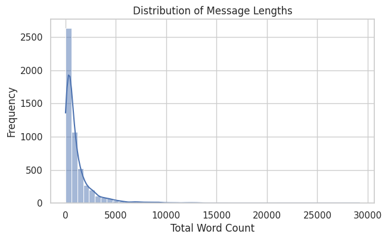

```python
plt.figure(figsize=(7,4))
sns.histplot(df["message_length"], bins=50, kde=True)
plt.title("Distribution of Message Lengths")
plt.xlabel("Total Word Count")
plt.ylabel("Frequency")
plt.show()
```

This code generates a comparative histogram that illustrates how message lengths differ between spam and non-spam (ham) emails. Using Seaborn’s histplot, it plots the message_length feature while applying the Prediction column as a hue, allowing spam and ham emails to be displayed in different colors on the same graph. The KDE (Kernel Density Estimate) curves provide smooth distribution lines for each class, making it easier to observe patterns and overlaps between the two categories. With properly labeled axes and a descriptive title, this graph helps highlight whether spam emails tend to be longer or shorter than legitimate ones—an insight that can contribute to better understanding feature behavior and improving the effectiveness of the classification model.

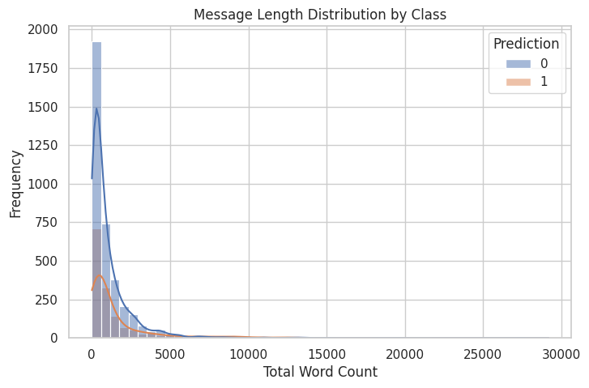

```python
plt.figure(figsize=(8,5))
sns.histplot(data=df, x="message_length", hue="Prediction", kde=True, bins=50)
plt.title("Message Length Distribution by Class")
plt.xlabel("Total Word Count")
plt.ylabel("Frequency")
plt.show()
```

This code produces a box plot to compare the distribution of message lengths between spam and non-spam emails. Using Seaborn’s boxplot, it displays statistical summaries—such as the median, quartiles, and potential outliers—of the message_length feature grouped by the Prediction class (0 = ham, 1 = spam). The visualization helps reveal whether there are notable differences in word count between the two categories, such as whether spam messages tend to be unusually short or long. With a clear title and axis labels, this plot provides an intuitive and concise view of how message length varies across classes, offering valuable insights into the separability of features in the classification task.

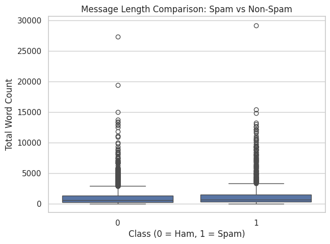

```python
plt.figure(figsize=(7,5))
sns.boxplot(x="Prediction", y="message_length", data=df)
plt.title("Message Length Comparison: Spam vs Non-Spam")
plt.xlabel("Class (0 = Ham, 1 = Spam)")
plt.ylabel("Total Word Count")
plt.show()
```

This code computes and visualizes the top 20 most frequently occurring words in the email dataset. After removing non-text columns such as Email No., Prediction, and message_length, it sums the remaining columns to obtain the total frequency of each word across all emails. The top 20 words are then selected using nlargest(). A horizontal bar chart generated with Seaborn clearly displays these dominant words, showing how often each appears in the dataset. This visualization helps identify common vocabulary trends, highlights repeated terms that may influence classification, and provides insight into language patterns present in both spam and non-spam emails.

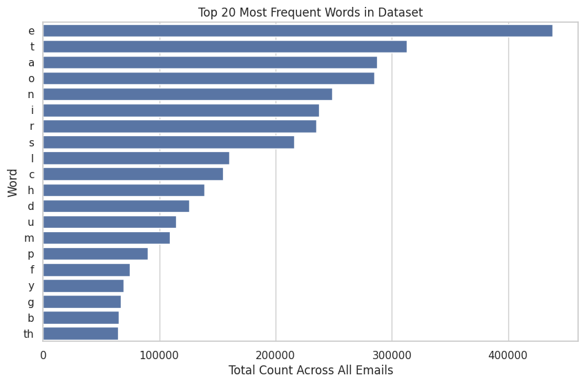

```python
# Calculate word frequencies (excluding 'Email No.', 'Prediction', and 'message_length' columns)
word_counts = df.drop(columns=['Email No.', 'Prediction', 'message_length']).sum()

# Get the top 20 most frequent words
top20 = word_counts.nlargest(20)

plt.figure(figsize=(10,6))
sns.barplot(x=top20.values, y=top20.index)
plt.title("Top 20 Most Frequent Words in Dataset")
plt.xlabel("Total Count Across All Emails")
plt.ylabel("Word")
plt.show()
```

```python
!pip install wordcloud
```

**Word Cloud for Spam Emails —**

This code generates a visual word cloud representing the most frequently occurring words in spam emails. First, the dataset is filtered to include only rows where the prediction class is 1 (Spam). All non-text columns (Email No., Prediction, and message_length) are removed, leaving only the bag-of-words features. The total frequency of each word is calculated and converted into a dictionary, which serves as input for the WordCloud generator. Using these frequencies, the WordCloud library creates a graphic where more frequent words appear larger and bolder. The resulting image is displayed with Matplotlib, accompanied by a title “Word Cloud – Spam Emails.” This visualization helps highlight the strongest textual patterns in spam messages and provides quick insight into the vocabulary commonly used in malicious or promotional content.

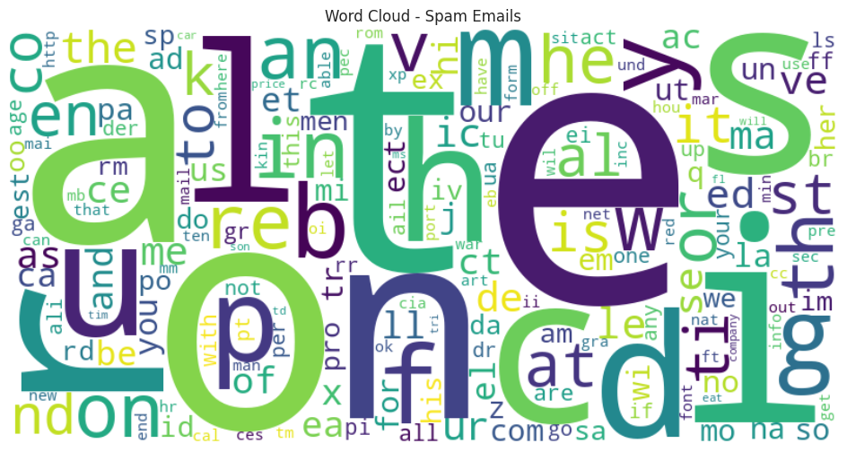

```python
from wordcloud import WordCloud

spam_df = df[df["Prediction"] == 1]
spam_bow = spam_df.drop(columns=["Email No.", "Prediction", "message_length"])

spam_freq = spam_bow.sum().to_dict()

wordcloud_spam = WordCloud(width=800, height=400, background_color="white").generate_from_frequencies(spam_freq)

plt.figure(figsize=(12,6))
plt.imshow(wordcloud_spam, interpolation="bilinear")
plt.axis("off")
plt.title("Word Cloud - Spam Emails")
plt.show()
```

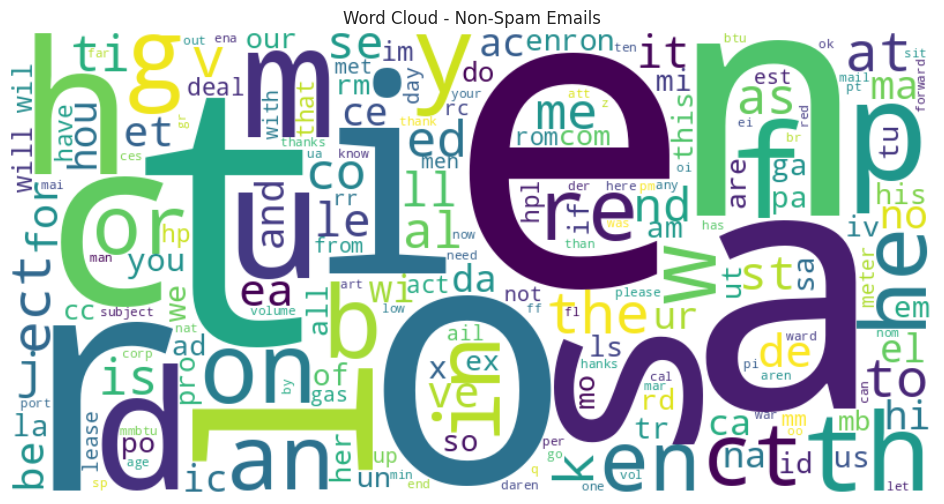

```python
ham_df = df[df["Prediction"] == 0]
ham_bow = ham_df.drop(columns=["Email No.", "Prediction", "message_length"])

ham_freq = ham_bow.sum().to_dict()

wordcloud_ham = WordCloud(width=800, height=400, background_color="white").generate_from_frequencies(ham_freq)

plt.figure(figsize=(12,6))
plt.imshow(wordcloud_ham, interpolation="bilinear")
plt.axis("off")
plt.title("Word Cloud - Non-Spam Emails")
plt.show()
```

**3. Text Preprocessing**

**Define Helper Functions:-**

This function, get_wordnet_pos, is used to map NLTK’s part-of-speech (POS) tags to the format required by WordNet, which improves the accuracy of lemmatization. Since WordNet expects specific POS categories such as noun, verb, adjective, or adverb, this function first checks the first letter of the POS tag generated by NLTK. If the tag starts with ‘J’, it is classified as an adjective; ‘V’ indicates a verb; ‘N’ is mapped to a noun; and ‘R’ corresponds to an adverb. Any tag that does not match these cases defaults to a noun. By converting the POS tags into WordNet-compatible formats, this function ensures that words are lemmatized more intelligently—for example, “running” becomes “run” when treated as a verb instead of a noun. This significantly improves the quality of text preprocessing in NLP tasks.

```python
from nltk.corpus import wordnet

def get_wordnet_pos(tag):
    if tag.startswith('J'):
        return wordnet.ADJ
    elif tag.startswith('V'):
        return wordnet.VERB
    elif tag.startswith('N'):
        return wordnet.NOUN
    elif tag.startswith('R'):
        return wordnet.ADV
    else:
        return wordnet.NOUN
```

**Cleaning Function:-**

The clean_text function performs fundamental text preprocessing to prepare raw email content for further NLP analysis. It begins by converting the entire text to lowercase to ensure uniformity and avoid treating the same word differently due to capitalization. Next, it removes all punctuation marks and numeric digits, which often do not contribute meaningful information to text classification tasks such as spam detection. The function also eliminates unnecessary whitespace by replacing multiple spaces with a single space and trimming any leading or trailing spaces. Overall, clean_text helps transform messy, raw text into a clean and simplified format, improving the effectiveness of tokenization, vectorization, and machine learning models.

```python
def clean_text(text):
    # Lowercase
    text = text.lower()
    # Remove punctuation
    text = text.translate(str.maketrans('', '', string.punctuation))
    # Remove digits
    text = re.sub(r'\d+', '', text)
    # Remove extra spaces
    text = re.sub(r'\s+', ' ', text).strip()

    return text
```

**Tokenization + Stopwords Removal + Lemmatization:-**

The preprocess_text function performs advanced text preprocessing to prepare email content for NLP modeling. It first calls the previously defined clean_text function to convert the text to lowercase, remove punctuation, digits, and extra spaces. The cleaned text is then tokenized into individual words using NLTK’s word_tokenize. Common English stopwords are removed to reduce noise and retain only meaningful words. Each remaining token is tagged with its part-of-speech (POS) using NLTK’s pos_tag function. Finally, the tokens are lemmatized using the WordNetLemmatizer, guided by the get_wordnet_pos function, which ensures that each word is reduced to its base form according to its correct POS category (e.g., verbs, nouns, adjectives). The lemmatized tokens are then joined back into a single string. This preprocessing pipeline helps standardize the text, reduce dimensionality, and improve the performance of machine learning models for spam detection.

```python
stop_words = set(stopwords.words('english'))
lemmatizer = WordNetLemmatizer()

def preprocess_text(text):
    text = clean_text(text)
    tokens = word_tokenize(text)
    tokens = [w for w in tokens if w not in stop_words]
    tagged = nltk.pos_tag(tokens)
    lemmatized = [
        lemmatizer.lemmatize(word, get_wordnet_pos(pos))
        for word, pos in tagged
    ]
    return " ".join(lemmatized)
```

Spell Correction (TextBlob)

```python
def correct_spelling(text):
    return str(TextBlob(text).correct())
```

SymSpell (Fast Spell Correction)

```python
!pip install symspellpy
from symspellpy import SymSpell, Verbosity
sym_spell = SymSpell(max_dictionary_edit_distance=2)
def sym_spell_fix(text):
    suggestions = sym_spell.lookup_compound(text, max_edit_distance=2)
    return suggestions[0].term
```

```
Downloading symspellpy-6.9.0-py3-none-any.whl (2.6 MB)
   ━━━━━━━━━━━━━━━━━━━━━━━━━━━━━━━━━━━━━━━━ 2.6/2.6 MB 26.8 MB/s eta 0:00:00
Downloading editdistpy-0.1.6-cp312-cp312-manylinux_2_5_x86_64.manylinux1_x86_64.manylinux_2_17_x86_64.manylinux2014_x86_64.whl (159 kB)
   ━━━━━━━━━━━━━━━━━━━━━━━━━━━━━━━━━━━━━━━━ 159.6/159.6 kB 10.6 MB/s eta 0:00:00
```

**Addressing Class Imbalance**

```python
!pip install imbalanced-learn
```

```python
# Drop ID column if present
df = df.drop(columns=["Email No."], errors='ignore')

# Features and Target
X = df.drop(columns=["Prediction"])
y = df["Prediction"]
```

```python
from sklearn.model_selection import train_test_split

X_train, X_test, y_train, y_test = train_test_split(
    X, y,
    test_size=0.2,
    random_state=42,
    stratify=y
)

X_train.shape, X_test.shape
```

```
((4137, 3001), (1035, 3001))
```

```python
from imblearn.over_sampling import SMOTE

# Create SMOTE object
smote = SMOTE(random_state=42)

# Apply SMOTE to training data only
X_train_smote, y_train_smote = smote.fit_resample(X_train, y_train)

print("Before SMOTE:", y_train.value_counts())
print("\nAfter SMOTE:", y_train_smote.value_counts())
```

```
Before SMOTE: Prediction
0    2937
1    1200
Name: count, dtype: int64

After SMOTE: Prediction
0    2937
1    2937
Name: count, dtype: int64
```

**Check Class Distribution Before SMOTE and After SMOTE:-**

This code applies SMOTE (Synthetic Minority Over-sampling Technique) to balance the class distribution in the training dataset. First, a SMOTE object is created with a fixed random seed to ensure reproducibility. The fit_resample method is then applied only to the training features (X_train) and labels (y_train), generating synthetic samples for the minority class (spam emails) to match the majority class (ham emails). The script prints the class distribution before and after SMOTE to demonstrate the effect of oversampling. Additionally, a side-by-side bar chart is created using Matplotlib, showing the count of each class before and after SMOTE. This visualization clearly illustrates how SMOTE balances the dataset, ensuring that the machine learning models are trained on a more equitable representation of both spam and non-spam emails, which helps improve model performance and reduces bias toward the majority class.

[output not shown]

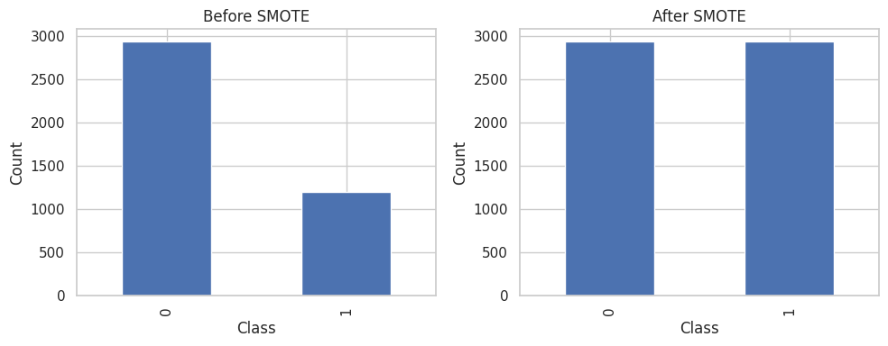

```python
from imblearn.over_sampling import SMOTE

# Create SMOTE object
smote = SMOTE(random_state=42)

# Apply SMOTE ONLY on training data
X_train_smote, y_train_smote = smote.fit_resample(X_train, y_train)

# Show class distribution before and after SMOTE
print(" BEFORE SMOTE ")
print(y_train.value_counts())

print("\n AFTER SMOTE ")
print(y_train_smote.value_counts())
import matplotlib.pyplot as plt

fig, ax = plt.subplots(1, 2, figsize=(10, 4))

# Before SMOTE
y_train.value_counts().plot(kind='bar', ax=ax[0])
ax[0].set_title("Before SMOTE")
ax[0].set_xlabel("Class")
ax[0].set_ylabel("Count")

# After SMOTE
y_train_smote.value_counts().plot(kind='bar', ax=ax[1])
ax[1].set_title("After SMOTE")
ax[1].set_xlabel("Class")
ax[1].set_ylabel("Count")

plt.tight_layout()
plt.show()
```

**4. Feature Engineering**

**Email Length Features:-**

This code block adds two new features to the dataset to enhance the predictive power of the spam detection model. The first feature, total_words, calculates the total word count for each email by summing all word-frequency columns while excluding the target column Prediction. The second feature, total_chars, provides an estimated character count for each email by multiplying total_words by an average word length of five characters. These features capture the overall length and density of the email content, which can be useful indicators for distinguishing between spam and non-spam messages. Finally, the first five rows of these new features are displayed to verify that the calculations have been applied correctly.

```python
# total words
df['total_words'] = df.drop(columns=['Prediction']).sum(axis=1)
df['total_chars'] = df['total_words'] * 5
# Show first 5 rows with new features
df[['total_words', 'total_chars']].head()
```

|  | total_words | total_chars |
| --- | --- | --- |
| 0 | 742 | 3710 |
| 1 | 30842 | 154210 |
| 2 | 1582 | 7910 |
| 3 | 14266 | 71330 |
| 4 | 15050 | 75250 |

**Special Spam Keyword Counts:-**

This code adds spam keyword indicator features to the dataset, which highlight the presence of words commonly associated with spam emails. A predefined list of spam-related words—such as "win", "free", "offer", "urgent", "money", and "click"—is iterated over, and for each word, a new column is created. If the word exists in the dataset’s bag-of-words columns, its original frequency is copied into the new feature; otherwise, the feature is set to zero. The resulting columns are named with the prefix kw_ (e.g., kw_win, kw_free) to indicate keyword features. These features help the machine learning models recognize emails containing terms that are strong indicators of spam. The first five rows of these keyword features are displayed to verify their creation and values.

```python
spam_words = ["win", "free", "offer", "urgent", "money", "credit", "prize",
              "lottery", "congratulations", "click", "buy", "discount"]
for word in spam_words:
    if word in df.columns:
        df[f'kw_{word}'] = df[word]
    else:
        df[f'kw_{word}'] = 0
df[[f'kw_{word}' for word in spam_words]].head()
```

|  | kw_win | kw_free | kw_offer | kw_urgent | kw_money | kw_credit | kw_prize | kw_lottery | kw_congratulations | kw_click | kw_buy | kw_discount |
| --- | --- | --- | --- | --- | --- | --- | --- | --- | --- | --- | --- | --- |
| 0 | 0 | 0 | 0 | 0 | 0 | 0 | 0 | 0 | 0 | 0 | 0 | 0 |
| 1 | 0 | 0 | 0 | 0 | 0 | 0 | 0 | 0 | 0 | 0 | 0 | 0 |
| 2 | 0 | 0 | 0 | 0 | 0 | 0 | 0 | 0 | 0 | 0 | 0 | 0 |
| 3 | 0 | 0 | 0 | 0 | 0 | 0 | 0 | 0 | 0 | 0 | 0 | 0 |
| 4 | 0 | 0 | 0 | 0 | 0 | 0 | 0 | 0 | 0 | 0 | 0 | 0 |

**Uppercase / Capitalization Ratio:-**

This code identifies and leverages columns representing fully capitalized words as a feature, which can indicate emphasis commonly found in spam emails. First, it scans all column names in the dataset and selects those that are entirely uppercase, excluding the target column Prediction. A sample of the detected capitalized columns is printed to verify the selection. Then, a new feature capital_word_count is created by summing the counts of these capitalized words for each email. If no capitalized columns exist, the feature is initialized to zero. This feature captures the frequency of emphatic or attention-grabbing words, which often appear in spam content. The first five rows of capital_word_count are displayed to confirm the feature has been successfully added.

```python
# IDENTIFY CAPITALIZED COLUMNS
capital_cols = [col for col in df.columns if col.isupper() and col not in ['Prediction']]

print("Capitalized Columns Found:", capital_cols[:10])  # Show sample column names

# CREATE FEATURE
if capital_cols:
    df['capital_word_count'] = df[capital_cols].sum(axis=1)
else:
    df['capital_word_count'] = 0

#  SHOW OUTPUT
df[['capital_word_count']].head()
```

```
Capitalized Columns Found: []
```

|  | capital_word_count |
| --- | --- |
| 0 | 0 |
| 1 | 0 |
| 2 | 0 |
| 3 | 0 |
| 4 | 0 |

**Count of Rare Words:-**

This code computes a rare word feature to help the model identify unusual or uncommon words in emails, which may be indicative of spam. First, the total frequency of each word across all emails is calculated by summing the columns, excluding the target column Prediction. Words whose total frequency falls in the bottom 5% are considered rare, and their indices are stored in rare_words. The number of rare words and a sample of the first 15 rare words are printed for verification. Next, for each email, the counts of these rare words are summed to create a new feature called rare_word_count. This feature captures the presence of low-frequency words, which can serve as a signal for spam detection. Finally, the first five values of rare_word_count are displayed to confirm the feature has been added correctly.

```python
# COMPUTE TOTAL FREQUENCY OF EACH WORD
word_totals = df.drop(columns=['Prediction']).sum()

#  IDENTIFY RARE WORDS (BOTTOM 5%)
threshold = word_totals.quantile(0.05)
rare_words = word_totals[word_totals <= threshold].index

print("Number of Rare Words Identified:", len(rare_words))
print("\nSample Rare Words:", list(rare_words[:15]))  # show first 15 rare words

# COUNT RARE WORDS PER EMAIL
df['rare_word_count'] = df[rare_words].sum(axis=1)

# SHOW OUTPUT
df[['rare_word_count']].head()
```

```
Number of Rare Words Identified: 160

Sample Rare Words: ['happened', 'easier', 'requires', 'nascar', 'confidence', 'ehronline', 'installed', 'busy', 'cheapest', 'disclosure', 'prohibited', 'processes', 'shareholders', 'supported', 'smoking']
```

|  | rare_word_count |
| --- | --- |
| 0 | 0 |
| 1 | 0 |
| 2 | 0 |
| 3 | 0 |
| 4 | 0 |

**5. Model Building**

**Importance of Model Building**

The importance of model building lies in its ability to automate the decision-making process, improve accuracy, and reduce human effort in manually filtering spam emails. A well-trained model provides a scalable solution that can handle large volumes of email efficiently. Without model building, the insights gained from data preprocessing and feature engineering would remain descriptive and could not be effectively applied to real-world spam detection tasks. Machine learning models thus serve as the core mechanism for turning data into actionable predictions.

```python
from sklearn.preprocessing import StandardScaler
from sklearn.linear_model import LogisticRegression
from sklearn.naive_bayes import MultinomialNB

from sklearn.metrics import (
    accuracy_score,
    precision_score,
    recall_score,
    f1_score,
    classification_report,
    confusion_matrix,
    roc_auc_score,
    roc_curve
)
RANDOM_SEED = 42
```

```python
try:
    X_train_smote = pd.DataFrame(X_train_smote, columns=X_train.columns)
    y_train_smote = pd.Series(y_train_smote, name='Prediction')
except Exception:
    pass

# Quick shape checks
print("X_train_smote:", getattr(X_train_smote, 'shape', None))
print("y_train_smote:", getattr(y_train_smote, 'shape', None))
print("X_test:", getattr(X_test, 'shape', None))
print("y_test:", getattr(y_test, 'shape', None))
```

```
X_train_smote: (5874, 3001)
y_train_smote: (5874,)
X_test: (1035, 3001)
y_test: (1035,)
```

Prepare features for each model

```python
scaler = StandardScaler()
X_train_scaled = scaler.fit_transform(X_train_smote)
X_test_scaled = scaler.transform(X_test)
```

Train Logistic Regression

```python
lr = LogisticRegression(max_iter=2000, random_state=RANDOM_SEED, solver='liblinear')
lr.fit(X_train_scaled, y_train_smote)
```

```
LogisticRegression(max_iter=2000, random_state=42, solver='liblinear')
```

Train Multinomial Naive Bayes

```python
X_train_nb = X_train_smote.values if isinstance(X_train_smote, pd.DataFrame) else X_train_smote
X_test_nb = X_test.values if isinstance(X_test, pd.DataFrame) else X_test
nb = MultinomialNB()
nb.fit(X_train_nb, y_train_smote)
```

```
MultinomialNB()
```

```python
y_pred_lr = lr.predict(X_test_scaled)
probs_lr = lr.predict_proba(X_test_scaled)[:, 1]
```

```python
y_pred_nb = nb.predict(X_test_nb)
probs_nb = nb.predict_proba(X_test_nb)[:, 1]
```

This code evaluates the performance of the Logistic Regression model on the test dataset using multiple classification metrics. It first prints key metrics including accuracy, precision, recall, and F1-score, which provide a quantitative assessment of the model’s ability to correctly classify spam and non-spam emails. Accuracy measures the overall correctness, precision indicates the proportion of predicted spam emails that are actually spam, recall captures how well the model identifies all actual spam emails, and F1-score provides a balanced measure of precision and recall. Additionally, the classification_report is printed to display a detailed breakdown of these metrics for each class, including support (the number of true instances per class). This evaluation helps determine the effectiveness and reliability of the Logistic Regression model for practical spam detection tasks.

```python
print("Logistic Regression Metrics ")
print("Accuracy :", accuracy_score(y_test, y_pred_lr))
print("Precision:", precision_score(y_test, y_pred_lr))
print("Recall   :", recall_score(y_test, y_pred_lr))
print("F1-score :", f1_score(y_test, y_pred_lr))

print("\nClassification Report:\n")
print(classification_report(y_test, y_pred_lr, digits=4))
```

```
Logistic Regression Metrics
Accuracy : 0.961352657004831
Precision: 0.9113924050632911
Recall   : 0.96
F1-score : 0.935064935064935

Classification Report:

              precision    recall  f1-score   support

           0     0.9833    0.9619    0.9725       735
           1     0.9114    0.9600    0.9351       300

    accuracy                         0.9614      1035
   macro avg     0.9474    0.9610    0.9538      1035
weighted avg     0.9625    0.9614    0.9616      1035
```

This code evaluates the performance of the Multinomial Naive Bayes model on the test dataset using standard classification metrics. It prints accuracy, precision, recall, and F1-score to quantify how well the model distinguishes between spam and non-spam emails. Accuracy indicates the overall proportion of correctly classified emails, precision measures the proportion of emails predicted as spam that are truly spam, recall assesses the model’s ability to identify all actual spam emails, and F1-score provides a balanced measure of precision and recall. The classification_report offers a detailed breakdown of these metrics for each class, including the number of true instances (support). This evaluation allows comparison of the Naive Bayes model with Logistic Regression and helps determine its effectiveness for real-world spam detection.

```python
print(" Naive Bayes Metrics")
print("Accuracy :", accuracy_score(y_test, y_pred_nb))
print("Precision:", precision_score(y_test, y_pred_nb))
print("Recall   :", recall_score(y_test, y_pred_nb))
print("F1-score :", f1_score(y_test, y_pred_nb))

print("\nClassification Report:\n")
print(classification_report(y_test, y_pred_nb, digits=4))
```

```
 Naive Bayes Metrics
Accuracy : 0.9565217391304348
Precision: 0.9022082018927445
Recall   : 0.9533333333333334
F1-score : 0.9270664505672609

Classification Report:

              precision    recall  f1-score   support

           0     0.9805    0.9578    0.9690       735
           1     0.9022    0.9533    0.9271       300

    accuracy                         0.9565      1035
   macro avg     0.9414    0.9556    0.9480      1035
weighted avg     0.9578    0.9565    0.9569      1035
```

This code visualizes the confusion matrix of the Logistic Regression model using a heatmap. The confusion_matrix function computes the number of true positives, true negatives, false positives, and false negatives by comparing the predicted labels (y_pred_lr) with the actual test labels (y_test). Seaborn’s heatmap is then used to display these counts in a visually intuitive format, with annotations for each cell and a blue color scale for clarity. The plot is labeled with a descriptive title, and the axes indicate predicted versus actual classes. This visualization provides a quick and clear understanding of how well the model distinguishes between spam and non-spam emails, highlighting areas where the model may misclassify.

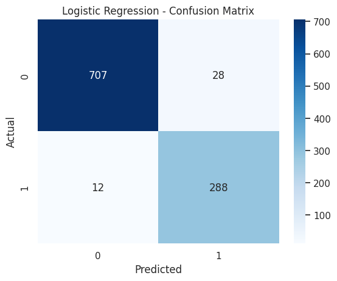

```python
cm_lr = confusion_matrix(y_test, y_pred_lr)
sns.heatmap(cm_lr, annot=True, fmt='d', cmap='Blues')
plt.title("Logistic Regression - Confusion Matrix")
plt.xlabel("Predicted")
plt.ylabel("Actual")
plt.show()
```

This code visualizes the confusion matrix for the Multinomial Naive Bayes model using a heatmap. The confusion_matrix function compares the predicted labels (y_pred_nb) with the true test labels (y_test) to calculate true positives, true negatives, false positives, and false negatives. Seaborn’s heatmap is then used to display these counts, with numeric annotations and a blue color gradient for clarity. The plot includes a descriptive title and labeled axes for predicted versus actual classes. This visualization provides an intuitive view of the model’s classification performance, allowing one to quickly assess how effectively the Naive Bayes model distinguishes between spam and non-spam emails and where misclassifications occur.

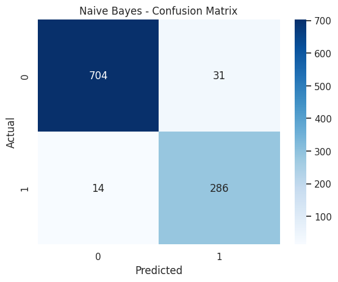

```python
cm_nb = confusion_matrix(y_test, y_pred_nb)
sns.heatmap(cm_nb, annot=True, fmt='d', cmap='Blues')
plt.title("Naive Bayes - Confusion Matrix")
plt.xlabel("Predicted")
plt.ylabel("Actual")
plt.show()
```

ROC Curves for Both Models:-

This code plots the ROC (Receiver Operating Characteristic) curves for both the Logistic Regression and Multinomial Naive Bayes models to evaluate their ability to distinguish between spam and non-spam emails. The false positive rate (fpr) and true positive rate (tpr) are computed for each model using the predicted probabilities, and the AUC (Area Under the Curve) score quantifies overall model performance. Both ROC curves are plotted on the same graph for direct comparison, with a dashed diagonal line representing a random baseline classifier. The plot includes labeled axes, a title, a legend indicating each model’s AUC, and a grid for better readability. This visualization helps assess model discrimination: the closer a curve follows the top-left corner, the better the model is at correctly identifying spam while minimizing false positives.

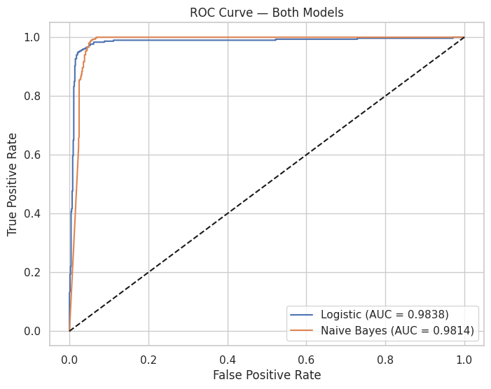

```python
plt.figure(figsize=(8,6))

# Logistic Regression
fpr_lr, tpr_lr, _ = roc_curve(y_test, probs_lr)
auc_lr = roc_auc_score(y_test, probs_lr)
plt.plot(fpr_lr, tpr_lr, label=f"Logistic (AUC = {auc_lr:.4f})")

# Naive Bayes
fpr_nb, tpr_nb, _ = roc_curve(y_test, probs_nb)
auc_nb = roc_auc_score(y_test, probs_nb)
plt.plot(fpr_nb, tpr_nb, label=f"Naive Bayes (AUC = {auc_nb:.4f})")

# Baseline
plt.plot([0,1], [0,1], 'k--')

plt.xlabel("False Positive Rate")
plt.ylabel("True Positive Rate")
plt.title("ROC Curve — Both Models")
plt.legend()
plt.grid(True)
plt.show()
```

**Saving Trained Models**

This code saves the trained machine learning models to disk using the joblib library, which is efficient for storing scikit-learn objects. The Logistic Regression model (lr) is saved as "logistic_regression_model.pkl", and the Multinomial Naive Bayes model (nb) is saved as "naive_bayes_model.pkl". Saving the models allows them to be reused later without retraining, enabling faster deployment or prediction on new email data. After the models are successfully stored, a confirmation message "Models saved successfully!" is printed to indicate that the operation has been completed. This step is essential for preserving the trained models for production or future experimentation.

```python
import joblib

# Save Logistic Regression model
joblib.dump(lr, "logistic_regression_model.pkl")
# Save Multinomial Naive Bayes model
joblib.dump(nb, "naive_bayes_model.pkl")
print("Models saved successfully!")
```

```
Models saved successfully!
```

**Future Scope:-**

1. Deploy the model using a web interface (Streamlit or Flask) for real-time spam prediction.
2. Integrate deep learning models such as LSTMs, GRUs, or Transformer-based architectures for improved accuracy.
3. Enhance text preprocessing by including stemming, lemmatization, and stopword filtering.
4. Build an end-to-end pipeline using Scikit-learn’s Pipeline and GridSearchCV for hyperparameter tuning.
5. mplement real-time email monitoring, integrating the model with actual email systems.
6. Apply advanced NLP techniques such as embeddings (Word2Vec, GloVe, BERT).